# Refinements Open Ended Assignment

Robert Thomas Kohn

9/15/25

# Refinement 1 - Begin Graphing in RStudio Open Ended Assignment 1

Question 1: Does a person having a child under 18 influence how often they fly annually?

```r
require(ggmosaic)
data(fly)
head(fly)
```

```
## # A tibble: 6 × 27
##           id flight_freq          do_you_recline      height  has_child_under_18
##        <dbl> <fct>                <fct>               <fct>   <fct>
## 1 3436139758 once a year or less  <NA>                 <NA>   <NA>
## 2 3434278696 once a year or less  about half the time "6'3\"" yes
## 3 3434275578 once a year or less  usually             "5'8\"" no
## 4 3434268208 once a year or less  always              "5'11\… no
## 5 3434250245 once a month or less about half the time "5'7\"" no
## 6 3434245875 once a year or less  usually             "5'9\"" yes
## # ℹ 22 more variables: three_seats_two_arms <fct>, two_seats_one_arm <fct>,
## #   window_shade <fct>, rude_to_move_to_unsold_seat <fct>,
## #   rude_to_talk_to_neighbor <fct>, six_hr_flight_leave_seat <fct>,
## #   reclining_obligation_to_behind <fct>, rude_to_recline <fct>,
## #   eliminate_reclining <fct>, rude_to_switch_seats_friends <fct>,
## #   rude_to_switch_seats_family <fct>, rude_to_wake_neighbor_bathroom <fct>,
## #   rude_to_wake_neighbor_walk <fct>, rude_to_bring_baby <fct>, …
```

```r
fly=na.omit(fly)


print("The Following is my Original Plot from Begin Graphing in RStudio Open Ended")
```

```
## [1] "The Following is my Original Plot from Begin Graphing in RStudio Open Ended"
```

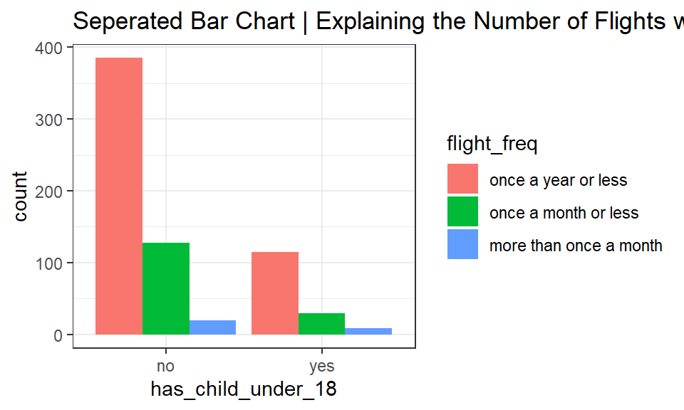

```r
gf_bar( ~ has_child_under_18 , data = fly , fill = ~ flight_freq,position = position_dodge( ), title="Seperated Bar Chart | Explaining the Number of Flights with if they have a minor" )
```

```r
print("The Following is my Revised Plot from Begin Graphing in RStudio Open Ended")
```

```
## [1] "The Following is my Revised Plot from Begin Graphing in RStudio Open Ended"
```

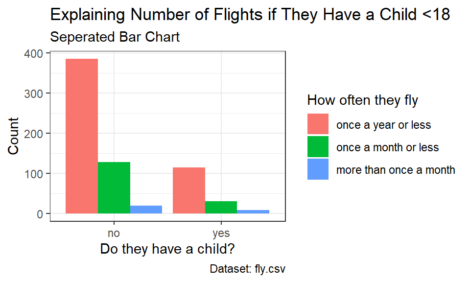

```r
gf_bar( ~ has_child_under_18 , data = fly , fill = ~ flight_freq,position = position_dodge( ))%>%gf_labs(x = "Do they have a child?", y = "Count", title="Explaining Number of Flights if They Have a Child <18" , subtitle = "Seperated Bar Chart" , caption = "Dataset: fly.csv", fill="How often they fly")
```

I feel like my intial graph was very strong but I felt it was necessary to revise it because it had flight_freq which made it gross and the axes labels were very unappealing. Now I feel like it is significantly better but I still wonder if there is a better title that could be used. Its hard to incorporate it without it being too long. Perhaps if there is a way to wrap text but even then that may be too wordy and take away from the graph.

# Refinement 2 - Begin Graphing in RStudio Open Ended Assignment 2

Question 2: Is there a relationship between a State’s Per Capita Income and the Winner of the 2008 Election?

```r
require(Stat2Data)
data(Election08)
head(Election08)
```

```
##         State Abr Income   HS   BA Dem.Rep ObamaWin
## 1    Alabama   AL  32404 80.4 21.4      -1        0
## 2     Alaska   AK  40352 90.5 26.0     -11        0
## 3    Arizona   AZ  33029 83.5 25.3       0        0
## 4   Arkansas   AR  30060 81.1 19.3      12        0
## 5 California   CA  41571 80.2 29.5      19        1
## 6   Colorado   CO  41042 88.9 35.0      11        1
```

```r
Election08$Winner <- ifelse(Election08$ObamaWin == 1, "Obama", "McCain")

print("The Following is my Original Plot from Begin Graphing in RStudio Open Ended")
```

```
## [1] "The Following is my Original Plot from Begin Graphing in RStudio Open Ended"
```

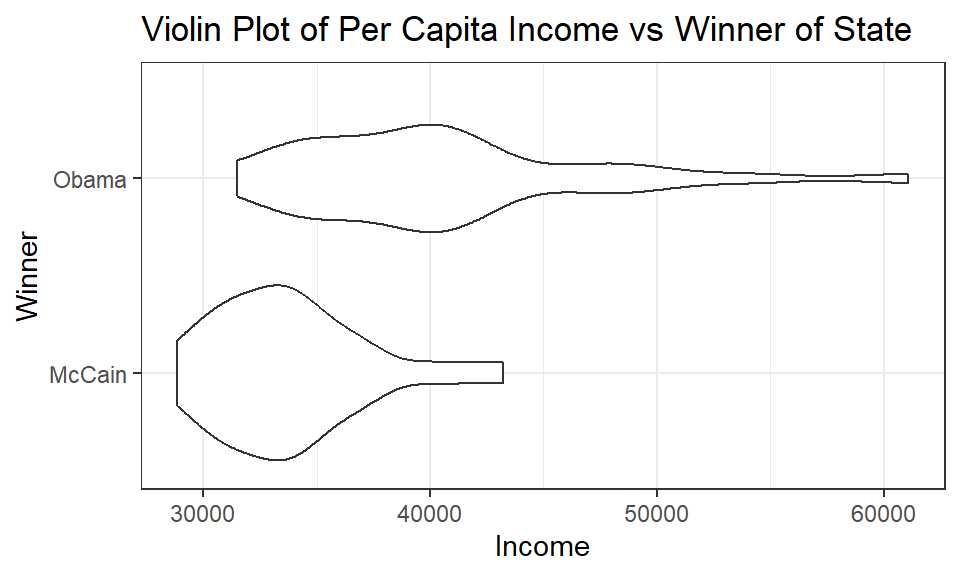

```r
gf_violin( Winner ~ Income , data = Election08 ,title="Violin Plot of Per Capita Income vs Winner of State")
```

```r
print("The Following is my Revised Plot from Begin Graphing in RStudio Open Ended")
```

```
## [1] "The Following is my Revised Plot from Begin Graphing in RStudio Open Ended"
```

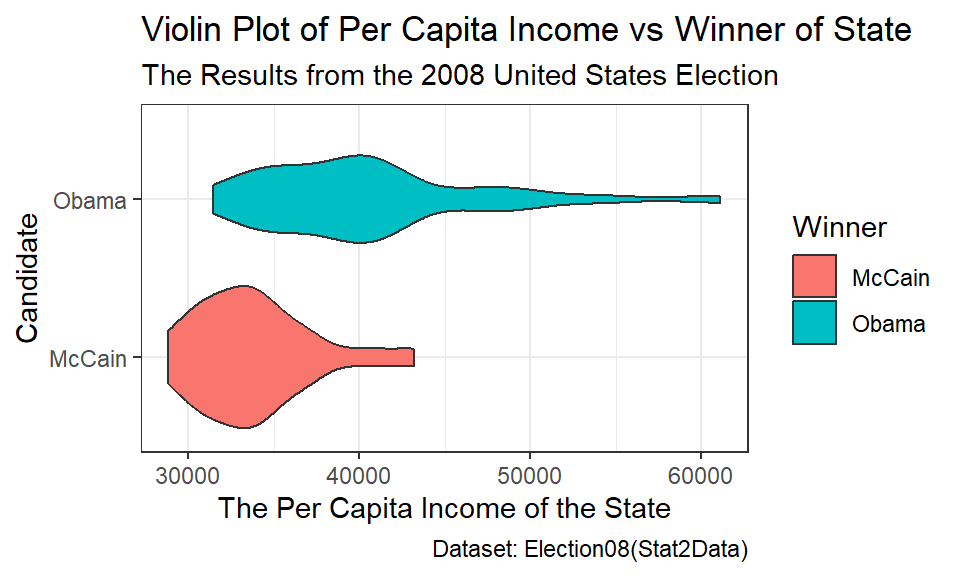

```r
gf_violin( Winner ~ Income , data = Election08, fill = ~Winner)%>%gf_labs(x = "The Per Capita Income of the State", y = "Candidate", title="Violin Plot of Per Capita Income vs Winner of State" , subtitle = "The Results from the 2008 United States Election" , caption = "Dataset: Election08(Stat2Data)")
```

I feel like the difference between the two is night and day fully. Not only are the individual violins filled in with the proper party colors but this whole graph looks relatively professional. It shows the candidates along side the per capita income and clearly labeled key and title. I am very content with this one.

# Is there a relationship between the percent of College Graudates and Democratic Lean in the 2016 Election?

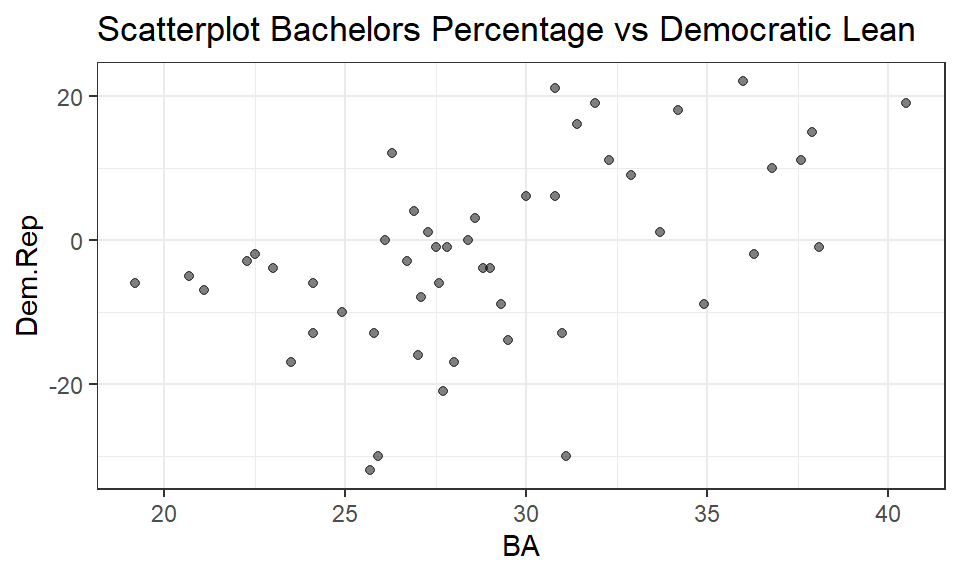

```r
#numericvnum
require(Stat2Data)
data(Election16)
gf_point( Dem.Rep ~ BA , data = Election16 , alpha = 0.5 , title="Scatterplot Bachelors Percentage vs Democratic Lean")
```

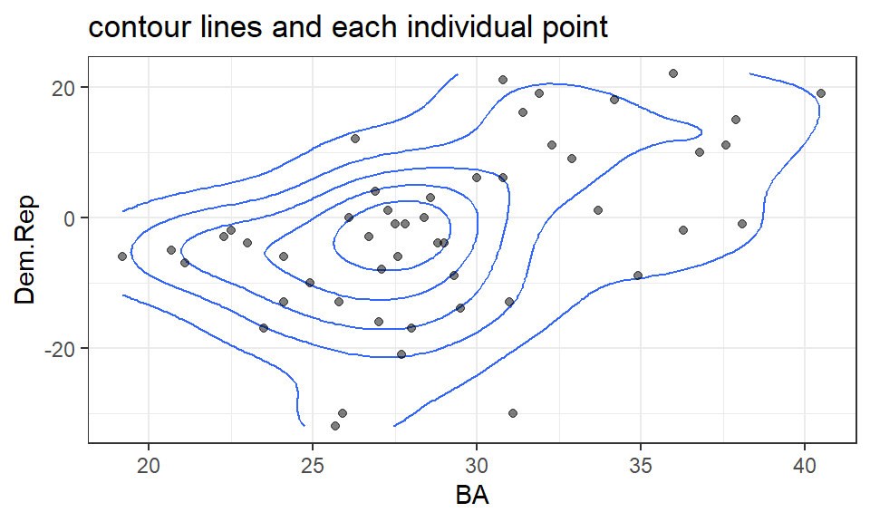

```r
gf_density_2d( Dem.Rep ~ BA , data = Election16, title="contour lines and each individual point") %>% gf_point(Dem.Rep ~ BA , data = Election16 , alpha = 0.5 )
```

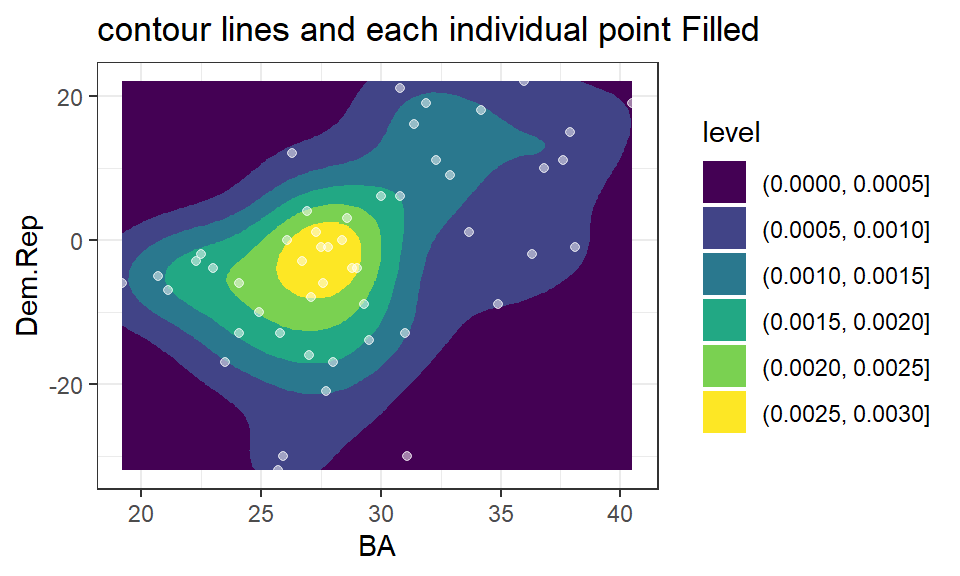

```r
gf_density_2d_filled( Dem.Rep ~ BA , data = Election16, title="contour lines and each individual point Filled") %>% gf_point(Dem.Rep ~ BA , data = Election16 , alpha = 0.5, color="white")
```

[figure not shown]

```r
#REVISED
gf_point( Dem.Rep ~ BA , data = Election16 , alpha = 0.5)%>%gf_labs(x = "The Per Capita Income of the State", y = "Political Party Lean", title="Scatterplot Bachelors Percentage vs Democratic Lean" , subtitle = "The Results from the 2016 United States Election" , caption = "Dataset: Election16(Stat2Data)")%>%gf_hline(yintercept = 0, linetype = "solid", color = "black", size=1)%>%gf_text( 20 ~ 20 , hjust = 0, label = "Democrat Lean" , size = 6 , color = "blue" )%>%gf_text( -20 ~ 30 , hjust = 0, label = "Republican Lean" , size = 6 , color = "red" )
```

# Is there a relationship between the weather and if the dogs were walked?

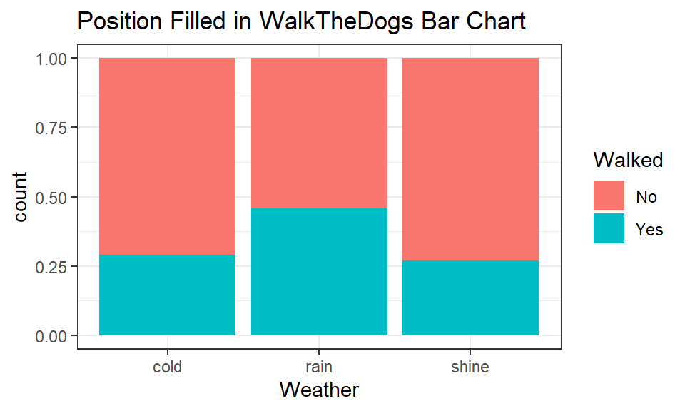

```r
#CATEGORICAL
data(WalkTheDogs )
WalkTheDogs$Walked <- ifelse(WalkTheDogs$Walk == 1, "Yes", "No")
gf_bar( ~ Weather , data = WalkTheDogs  , fill = ~ Walked , position = position_fill( ),title="Position Filled in WalkTheDogs Bar Chart"  )
```

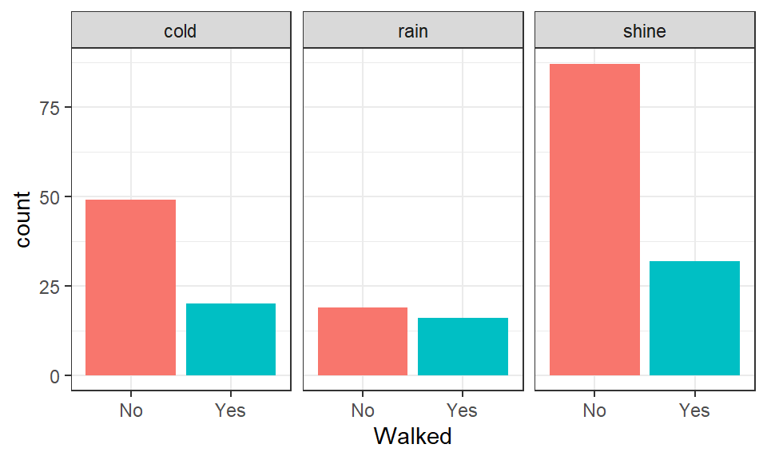

```r
gf_bar(~Walked, data = WalkTheDogs , fill = ~Walked, show.legend = FALSE) %>% gf_facet_wrap(~Weather)
```

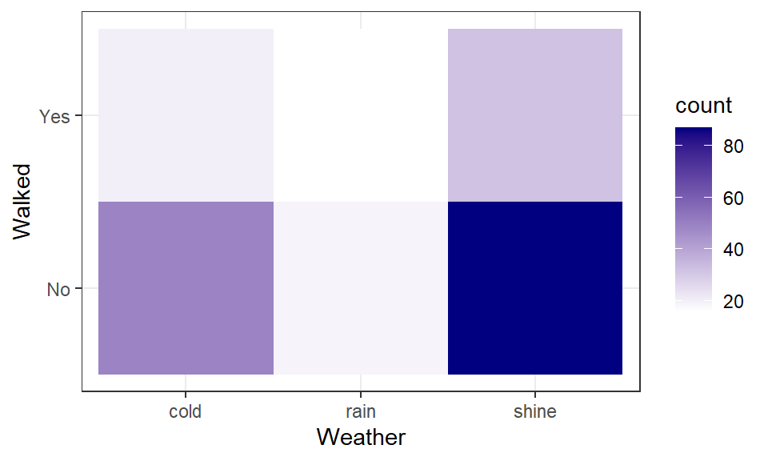

```r
gf_bin2d(Walked~Weather, data=WalkTheDogs ) %>%
gf_refine(scale_fill_continuous(low = "white", high = "navy"))
```

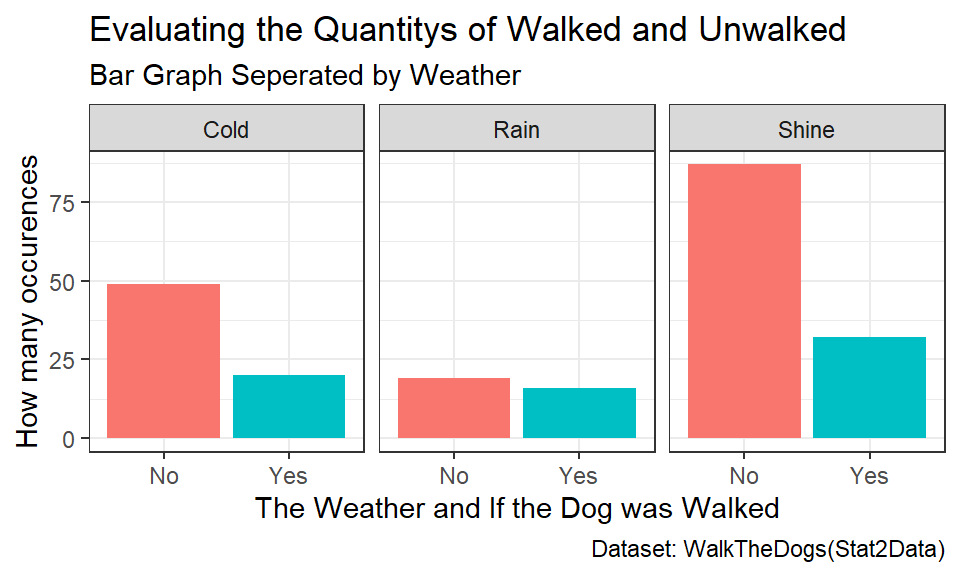

```r
#REVISED
gf_bar(~Walked, data = WalkTheDogs , fill = ~Walked, show.legend = FALSE) %>% gf_facet_wrap(~Weather, labeller = labeller(Weather = c("cold" = "Cold", "rain" = "Rain", "shine"="Shine")))%>%gf_labs(x = "The Weather and If the Dog was Walked", y = "How many occurences", title="Evaluating the Quantitys of Walked and Unwalked" , subtitle = "Bar Graph Seperated by Weather" , caption = "Dataset: WalkTheDogs(Stat2Data)" )
```

# Is there a relationship between the rater’s sex and how they rate someone’s sexual dimorphism?

```r
#1n1
data(FaithfulFaces)
library(ggridges)
```

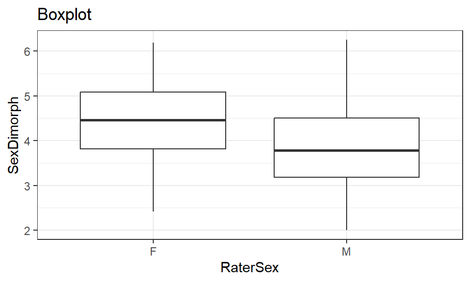

```r
gf_boxplot( SexDimorph ~ RaterSex , data = FaithfulFaces , options,title="Boxplot")
```

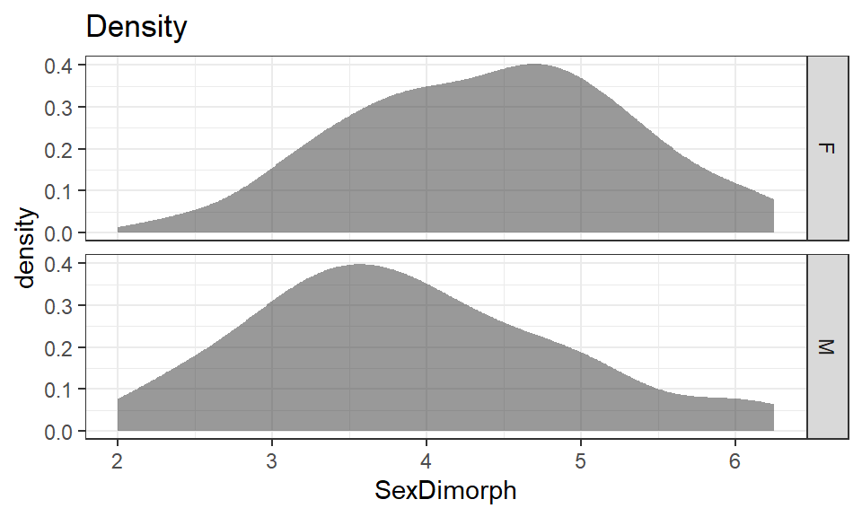

```r
gf_density(~SexDimorph, data = FaithfulFaces,title="Density") %>%
gf_facet_wrap(~RaterSex, ncol=1, strip.position = "right")
```

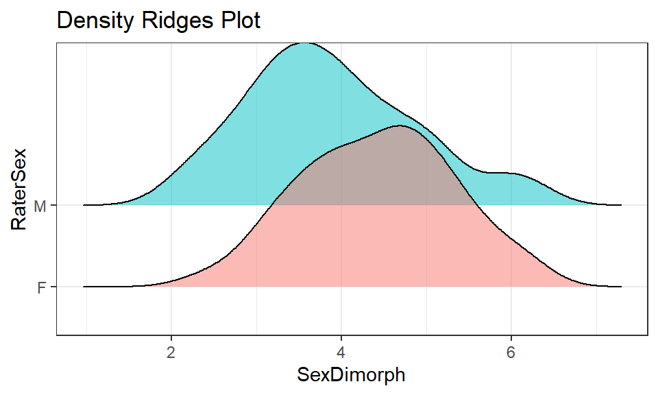

```r
gf_density_ridges(RaterSex~SexDimorph, data=FaithfulFaces, fill=~RaterSex, show.legend = FALSE, scale = 2, alpha = 0.5,title="Density Ridges Plot")
```

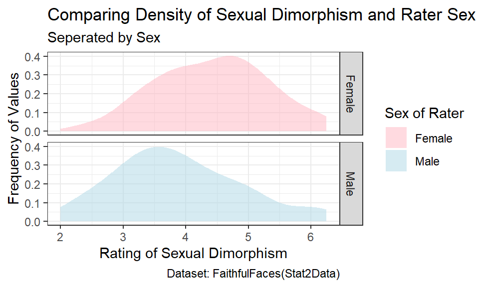

```r
#

#REVISED
gf_density(~SexDimorph, data = FaithfulFaces, fill=~RaterSex) %>% gf_facet_wrap(~RaterSex, ncol=1, strip.position = "right", labeller = labeller(RaterSex = c("F" = "Female", "M" = "Male"))) %>%gf_labs(x = "Rating of Sexual Dimorphism", y = "Frequency of Values", title="Comparing Density of Sexual Dimorphism and Rater Sex" , subtitle = "Seperated by Sex" , caption = "Dataset: FaithfulFaces(Stat2Data)") + scale_fill_manual(values = c("F" = "lightpink", "M" = "lightblue"), labels = c("F" = "Female", "M" = "Male"), name = "Sex of Rater")
```